# Term Deposit Subscription Prediction

## Objective

Using the data collected from existing customers, build a model that will help the marketing team identify potential customers who are relatively more likely to subscribe term deposit and thus increase their hit ratio.

## Attribute Information

### Bank client data:

- age: Continuous feature
- job: Type of job (management, technician, entrepreneur, blue-collar, etc.)
- marital: marital status (married, single, divorced)
- education: education level (primary, secondary, tertiary)
- default: has credit in default?
- housing: has housing loan?
- loan: has personal loan?
- balance: balance in account

### Related to previous contact:

- contact: contact communication type
- month: last contact month of year
- day: last contact day of the month
- duration: last contact duration, in seconds

### Other attributes:

- campaign: number of contacts performed during this campaign and for this client
- pdays: number of days that passed by after the client was last contacted from a previous campaign (-1 tells us the person has not been contacted or contact period is beyond 900 days)
- previous: number of times the client has been contacted before for the last campaign to subscribe term deposit
- poutcome: outcome of the previous marketing campaign

### Output variable (target variable):

- Target: Tell us has the client subscribed a term deposit. (Yes, No)

```python
import warnings
warnings.filterwarnings('ignore')
```

### Import Libraries

```python
import pandas as pd
import numpy as np
import matplotlib.pyplot as plt
%matplotlib inline
import seaborn as sns

from sklearn.linear_model import LogisticRegression
from sklearn.model_selection import train_test_split
from sklearn.ensemble import RandomForestClassifier
from scipy import stats

# calculate accuracy measures and confusion matrix, f1 score, ROC AUC
from sklearn.metrics import confusion_matrix, recall_score, precision_score, f1_score, roc_auc_score, accuracy_score

from yellowbrick.classifier import ClassificationReport, ROCAUC

plt.style.use('ggplot')
pd.options.display.float_format = '{:,.2f}'.format
from IPython.core.display import display, HTML
display(HTML("<style>.container { width:95% !important; }</style>"))
```

```python
# importing data
df = pd.read_csv('bank-full.csv')
```

### Overview of Data

```python
df.shape
```

```
(45211, 17)
```

```python
df.sample(10)
```

|  | age | job | marital | education | default | balance | housing | loan | contact | day | month | duration | campaign | pdays | previous | poutcome | Target |
| --- | --- | --- | --- | --- | --- | --- | --- | --- | --- | --- | --- | --- | --- | --- | --- | --- | --- |
| 25646 | 39 | management | married | tertiary | no | -233 | yes | no | cellular | 19 | nov | 249 | 1 | -1 | 0 | unknown | no |
| 685 | 54 | services | married | secondary | no | 510 | yes | no | unknown | 6 | may | 196 | 2 | -1 | 0 | unknown | no |
| 20515 | 33 | technician | single | secondary | yes | 329 | no | no | cellular | 12 | aug | 137 | 2 | -1 | 0 | unknown | no |
| 16718 | 43 | unemployed | divorced | secondary | no | 0 | yes | no | cellular | 24 | jul | 229 | 2 | -1 | 0 | unknown | no |
| 42853 | 52 | blue-collar | married | secondary | no | 955 | no | yes | cellular | 3 | feb | 153 | 1 | 48 | 3 | success | yes |
| 40065 | 29 | student | single | secondary | no | 1779 | no | no | cellular | 4 | jun | 400 | 1 | -1 | 0 | unknown | yes |
| 42319 | 35 | technician | married | tertiary | no | 3160 | yes | no | cellular | 16 | nov | 445 | 2 | 95 | 1 | failure | yes |
| 2171 | 26 | blue-collar | single | secondary | yes | -23 | yes | no | unknown | 12 | may | 315 | 1 | -1 | 0 | unknown | no |
| 36309 | 32 | blue-collar | single | secondary | no | -84 | yes | no | cellular | 11 | may | 426 | 1 | -1 | 0 | unknown | no |
| 15722 | 54 | technician | divorced | secondary | no | 859 | no | yes | cellular | 21 | jul | 710 | 1 | -1 | 0 | unknown | yes |

```python
df.dtypes
```

```
age           int64
job          object
marital      object
education    object
default      object
balance       int64
housing      object
loan         object
contact      object
day           int64
month        object
duration      int64
campaign      int64
pdays         int64
previous      int64
poutcome     object
Target       object
dtype: object
```

```python
df.nunique()
```

```
age            77
job            12
marital         3
education       4
default         2
balance      7168
housing         2
loan            2
contact         3
day            31
month          12
duration     1573
campaign       48
pdays         559
previous       41
poutcome        4
Target          2
dtype: int64
```

```python
df.info()
```

```
<class 'pandas.core.frame.DataFrame'>
RangeIndex: 45211 entries, 0 to 45210
Data columns (total 17 columns):
 #   Column     Non-Null Count  Dtype
---  ------     --------------  -----
 0   age        45211 non-null  int64
 1   job        45211 non-null  object
 2   marital    45211 non-null  object
 3   education  45211 non-null  object
 4   default    45211 non-null  object
 5   balance    45211 non-null  int64
 6   housing    45211 non-null  object
 7   loan       45211 non-null  object
 8   contact    45211 non-null  object
 9   day        45211 non-null  int64
 10  month      45211 non-null  object
 11  duration   45211 non-null  int64
 12  campaign   45211 non-null  int64
 13  pdays      45211 non-null  int64
 14  previous   45211 non-null  int64
 15  poutcome   45211 non-null  object
 16  Target     45211 non-null  object
dtypes: int64(7), object(10)
memory usage: 5.9+ MB
```

```python
df.isnull().sum()
```

```
age          0
job          0
marital      0
education    0
default      0
balance      0
housing      0
loan         0
contact      0
day          0
month        0
duration     0
campaign     0
pdays        0
previous     0
poutcome     0
Target       0
dtype: int64
```

Given that we have a total of 45211 rows of data, we can see from the info in the two preceding cells that we do not have any null values for any of the columns in our dataset, since they all show 45211 non-null value counts, which is confirmed with df.isnull().sum() output

### List all possible values for job, marital, education, contact, poutcome

```python
df['job'].unique()
```

```
array(['management', 'technician', 'entrepreneur', 'blue-collar',
       'unknown', 'retired', 'admin.', 'services', 'self-employed',
       'unemployed', 'housemaid', 'student'], dtype=object)
```

```python
df['marital'].unique()
```

```
array(['married', 'single', 'divorced'], dtype=object)
```

```python
df['education'].unique()
```

```
array(['tertiary', 'secondary', 'unknown', 'primary'], dtype=object)
```

```python
df['contact'].unique()
```

```
array(['unknown', 'cellular', 'telephone'], dtype=object)
```

```python
df['poutcome'].unique()
```

```
array(['unknown', 'failure', 'other', 'success'], dtype=object)
```

## Univariat Analysis

```python
df.describe().transpose()
```

|  | count | mean | std | min | 25% | 50% | 75% | max |
| --- | --- | --- | --- | --- | --- | --- | --- | --- |
| age | 45,211.00 | 40.94 | 10.62 | 18.00 | 33.00 | 39.00 | 48.00 | 95.00 |
| balance | 45,211.00 | 1,362.27 | 3,044.77 | -8,019.00 | 72.00 | 448.00 | 1,428.00 | 102,127.00 |
| day | 45,211.00 | 15.81 | 8.32 | 1.00 | 8.00 | 16.00 | 21.00 | 31.00 |
| duration | 45,211.00 | 258.16 | 257.53 | 0.00 | 103.00 | 180.00 | 319.00 | 4,918.00 |
| campaign | 45,211.00 | 2.76 | 3.10 | 1.00 | 1.00 | 2.00 | 3.00 | 63.00 |
| pdays | 45,211.00 | 40.20 | 100.13 | -1.00 | -1.00 | -1.00 | -1.00 | 871.00 |
| previous | 45,211.00 | 0.58 | 2.30 | 0.00 | 0.00 | 0.00 | 0.00 | 275.00 |

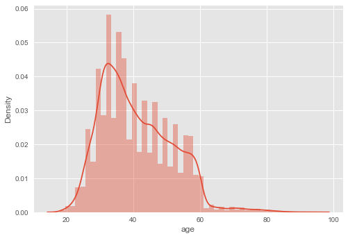

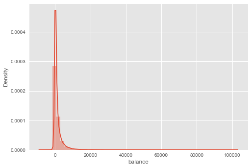

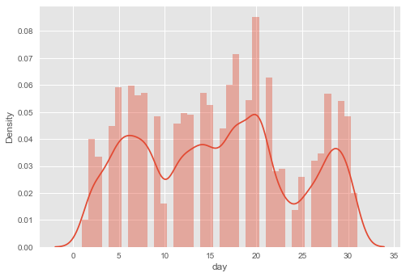

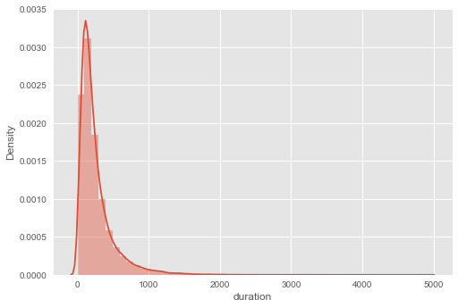

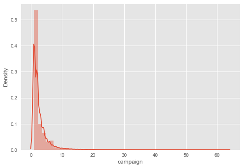

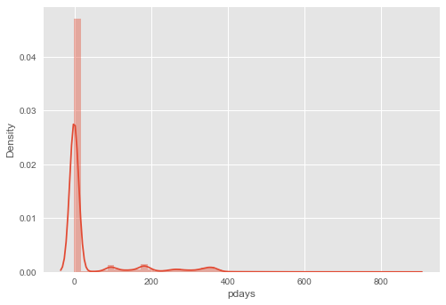

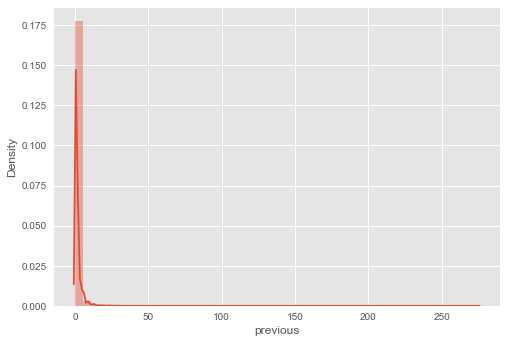

```python
# distplot for continous columns
for i in ['age', 'balance', 'day', 'duration', 'campaign', 'pdays', 'previous']:
    sns.distplot(df[i], kde=True)
    plt.show()
```

```python
df.skew()
```

```
age         0.68
balance     8.36
day         0.09
duration    3.14
campaign    4.90
pdays       2.62
previous   41.85
dtype: float64
```

#### Insights:

We see that balance, duration, campaign, pdays, and previous are all skewed, with previous and balance being highly skewed. All these variables are expected to be skewed, such as balance, where many will have smaller balance, same as campaign, pdays, and previous. Also, duration it is not known before a call is performed. Also, after the end of the call y is obviously known. Thus, this input is only included for benchmark purposes and will be discarded in order to create a realistic predictive model.

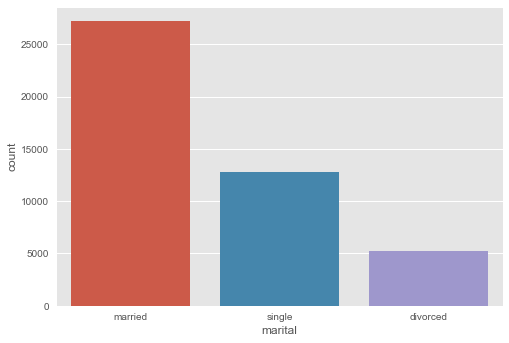

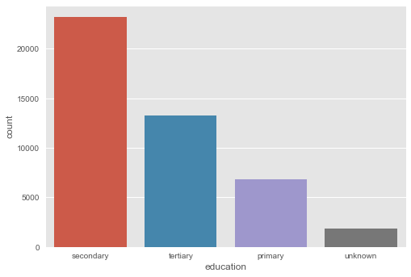

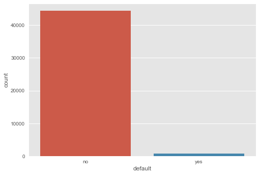

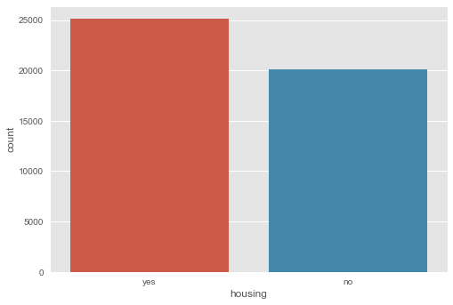

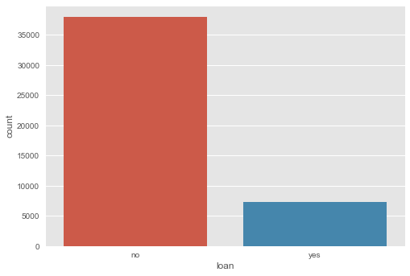

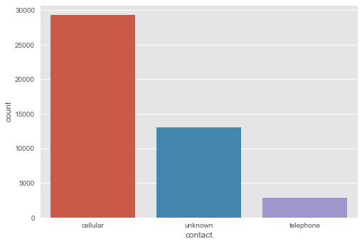

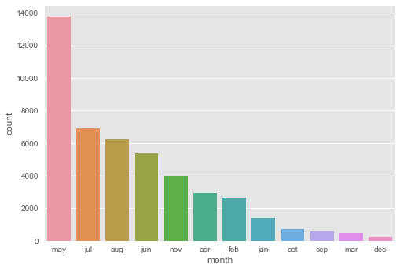

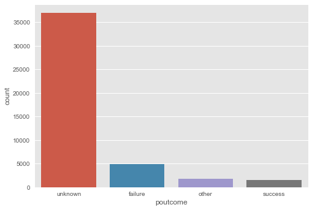

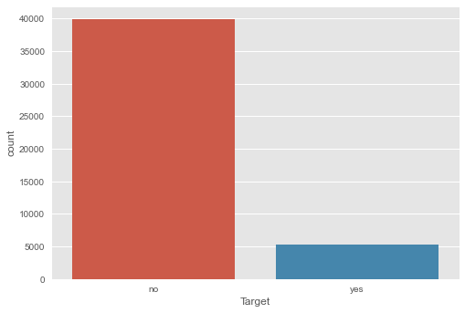

```python
for i in ['marital', 'education', 'default', 'housing', 'loan', 'contact', 'month', 'poutcome', 'Target']:
    sns.countplot(df[i], order = df[i].value_counts().index)
    plt.show()
```

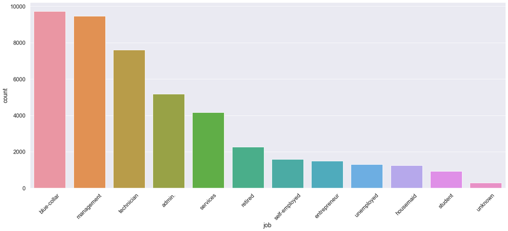

```python
plt.figure(figsize=(25, 10))
sns.set(font_scale=1.5)
job_plot = sns.countplot(x = df['job'],data = df, order = df['job'].value_counts().index)
job_plot.set_xticklabels(job_plot.get_xticklabels(), rotation=45)
plt.show()
```

### Multivariate Analysis

```python
for i in list(df.columns[df.dtypes=='object']):   # checking value counts of all object type columns
    print(df[i].value_counts(normalize=True))
    print()
```

```
blue-collar     0.22
management      0.21
technician      0.17
admin.          0.11
services        0.09
retired         0.05
self-employed   0.03
entrepreneur    0.03
unemployed      0.03
housemaid       0.03
student         0.02
unknown         0.01
Name: job, dtype: float64

married    0.60
single     0.28
divorced   0.12
Name: marital, dtype: float64

secondary   0.51
tertiary    0.29
primary     0.15
unknown     0.04
Name: education, dtype: float64

no    0.98
yes   0.02
Name: default, dtype: float64

yes   0.56
no    0.44
Name: housing, dtype: float64

no    0.84
yes   0.16
Name: loan, dtype: float64

cellular    0.65
unknown     0.29
telephone   0.06
```

[output cut: 10 more lines]

```
oct   0.02
sep   0.01
mar   0.01
dec   0.00
Name: month, dtype: float64

unknown   0.82
failure   0.11
other     0.04
success   0.03
Name: poutcome, dtype: float64

no    0.88
yes   0.12
Name: Target, dtype: float64
```

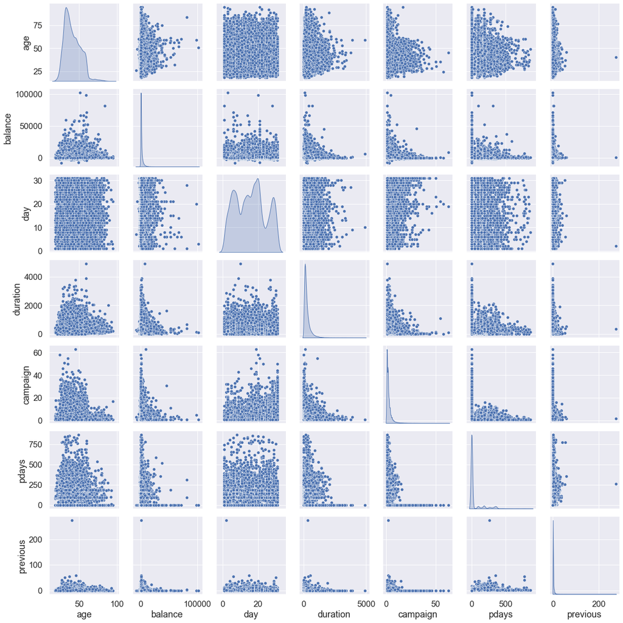

```python
sns.pairplot(df,diag_kind='kde')
plt.show()
```

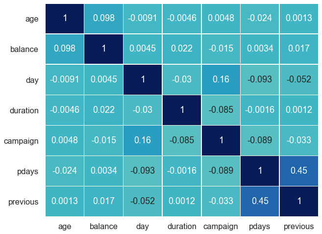

```python
plt.figure(figsize=(10,8))
sns.heatmap(df.corr(),
            annot=True,
            linewidths=.5,
            center=0,
            cbar=False,
            cmap="YlGnBu")
plt.show()
```

```python
df_copy = df.copy()
```

```python
# df_copy['marital'] = df_copy['marital'].astype('category')
# df_copy['Target'] = df_copy['Target'].astype('category')
```

```python
binary_replace = {"Target" : {"no": 0, "yes": 1},
                    "default": {"no": 0, "yes": 1},
                     "housing": {"no": 0, "yes": 1},
                     "loan": {"no": 0, "yes": 1}}
df_copy.replace(binary_replace, inplace=True)
df_copy.sample(10)
```

|  | age | job | marital | education | default | balance | housing | loan | contact | day | month | duration | campaign | pdays | previous | poutcome | Target |
| --- | --- | --- | --- | --- | --- | --- | --- | --- | --- | --- | --- | --- | --- | --- | --- | --- | --- |
| 21697 | 32 | technician | single | secondary | 0 | 29 | 0 | 0 | cellular | 19 | aug | 156 | 2 | -1 | 0 | unknown | 0 |
| 40230 | 30 | technician | single | secondary | 0 | 601 | 0 | 0 | cellular | 12 | jun | 80 | 3 | 105 | 1 | failure | 0 |
| 33301 | 43 | blue-collar | married | secondary | 0 | 1927 | 1 | 0 | cellular | 20 | apr | 149 | 1 | 152 | 1 | failure | 0 |
| 965 | 43 | admin. | married | secondary | 0 | 71 | 0 | 0 | unknown | 7 | may | 180 | 5 | -1 | 0 | unknown | 0 |
| 17831 | 47 | services | single | secondary | 0 | 591 | 0 | 0 | cellular | 29 | jul | 397 | 1 | -1 | 0 | unknown | 0 |
| 8199 | 34 | services | single | secondary | 0 | -96 | 1 | 0 | unknown | 2 | jun | 269 | 3 | -1 | 0 | unknown | 0 |
| 18326 | 50 | technician | married | secondary | 0 | 1518 | 0 | 1 | cellular | 31 | jul | 321 | 2 | -1 | 0 | unknown | 0 |
| 37133 | 28 | admin. | divorced | secondary | 0 | 451 | 1 | 0 | cellular | 13 | may | 302 | 1 | 301 | 1 | success | 1 |
| 37858 | 55 | services | single | secondary | 0 | 1126 | 1 | 0 | telephone | 14 | may | 166 | 1 | -1 | 0 | unknown | 0 |
| 10447 | 59 | retired | married | primary | 0 | 4949 | 0 | 1 | unknown | 12 | jun | 168 | 8 | -1 | 0 | unknown | 0 |

```python
df_copy['education'].unique()
```

```
array(['tertiary', 'secondary', 'unknown', 'primary'], dtype=object)
```

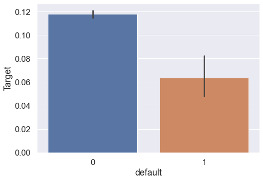

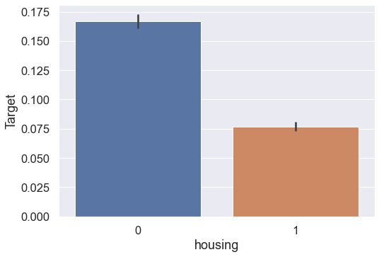

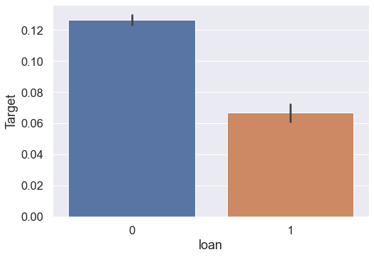

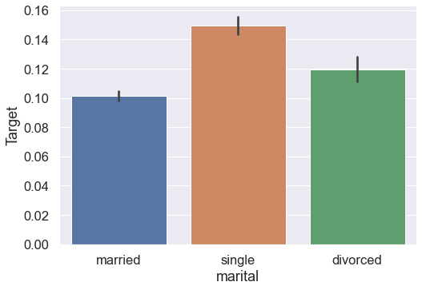

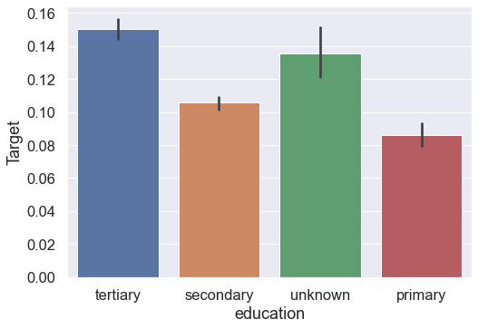

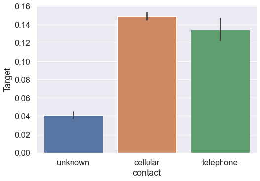

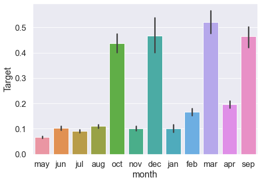

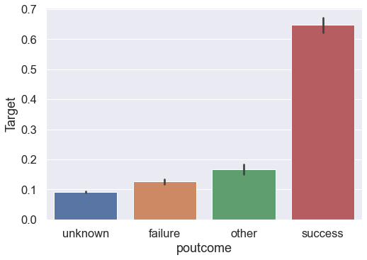

```python
# change education to specific numbering since it is ordinal variable
for i in  ['default', 'housing', 'loan', 'marital', 'education', 'contact', 'month', 'poutcome']:
    sns.barplot(df_copy[i], df_copy['Target'])
    plt.show()
```

```python
df.groupby(['Target']).mean()
```

| Target | age | balance | day | duration | campaign | pdays | previous |
| --- | --- | --- | --- | --- | --- | --- | --- |
| no | 40.84 | 1,303.71 | 15.89 | 221.18 | 2.85 | 36.42 | 0.50 |
| yes | 41.67 | 1,804.27 | 15.16 | 537.29 | 2.14 | 68.70 | 1.17 |

```python
df_copy.groupby(['Target']).median()
```

| Target | age | default | balance | housing | loan | day | duration | campaign | pdays | previous |
| --- | --- | --- | --- | --- | --- | --- | --- | --- | --- | --- |
| 0 | 39 | 0 | 417 | 1 | 0 | 16 | 164 | 2 | -1 | 0 |
| 1 | 38 | 0 | 733 | 0 | 0 | 15 | 426 | 2 | -1 | 0 |

```python
pd.crosstab(df_copy['job'], df_copy['Target'], normalize='index')
```

| Target job | 0 | 1 |
| --- | --- | --- |
| admin. | 0.88 | 0.12 |
| blue-collar | 0.93 | 0.07 |
| entrepreneur | 0.92 | 0.08 |
| housemaid | 0.91 | 0.09 |
| management | 0.86 | 0.14 |
| retired | 0.77 | 0.23 |
| self-employed | 0.88 | 0.12 |
| services | 0.91 | 0.09 |
| student | 0.71 | 0.29 |
| technician | 0.89 | 0.11 |
| unemployed | 0.84 | 0.16 |
| unknown | 0.88 | 0.12 |

```python
pd.crosstab(df_copy['marital'], df_copy['Target'], normalize='index')
```

| Target marital | 0 | 1 |
| --- | --- | --- |
| divorced | 0.88 | 0.12 |
| married | 0.90 | 0.10 |
| single | 0.85 | 0.15 |

```python
pd.crosstab(df_copy['education'], df_copy['Target'], normalize='index')
```

| Target education | 0 | 1 |
| --- | --- | --- |
| primary | 0.91 | 0.09 |
| secondary | 0.89 | 0.11 |
| tertiary | 0.85 | 0.15 |
| unknown | 0.86 | 0.14 |

```python
pd.crosstab(df_copy['default'], df_copy['Target'], normalize='index')
```

| Target default | 0 | 1 |
| --- | --- | --- |
| 0 | 0.88 | 0.12 |
| 1 | 0.94 | 0.06 |

```python
pd.crosstab(df_copy['housing'], df_copy['Target'], normalize='index')
```

| Target housing | 0 | 1 |
| --- | --- | --- |
| 0 | 0.83 | 0.17 |
| 1 | 0.92 | 0.08 |

```python
pd.crosstab(df_copy['loan'], df_copy['Target'], normalize='index')
```

| Target loan | 0 | 1 |
| --- | --- | --- |
| 0 | 0.87 | 0.13 |
| 1 | 0.93 | 0.07 |

```python
pd.crosstab(df_copy['contact'], df_copy['Target'], normalize='index')
```

| Target contact | 0 | 1 |
| --- | --- | --- |
| cellular | 0.85 | 0.15 |
| telephone | 0.87 | 0.13 |
| unknown | 0.96 | 0.04 |

```python
pd.crosstab(df_copy['month'], df_copy['Target'], normalize='index')
```

| Target month | 0 | 1 |
| --- | --- | --- |
| apr | 0.80 | 0.20 |
| aug | 0.89 | 0.11 |
| dec | 0.53 | 0.47 |
| feb | 0.83 | 0.17 |
| jan | 0.90 | 0.10 |
| jul | 0.91 | 0.09 |
| jun | 0.90 | 0.10 |
| mar | 0.48 | 0.52 |
| may | 0.93 | 0.07 |
| nov | 0.90 | 0.10 |
| oct | 0.56 | 0.44 |
| sep | 0.54 | 0.46 |

```python
pd.crosstab(df_copy['poutcome'], df_copy['Target'], normalize='index')
```

| Target poutcome | 0 | 1 |
| --- | --- | --- |
| failure | 0.87 | 0.13 |
| other | 0.83 | 0.17 |
| success | 0.35 | 0.65 |
| unknown | 0.91 | 0.09 |

## Preparing data for analytics

```python
# drop duration for reasons mentioned above
df_copy = df_copy.drop('duration', axis=1)
df_copy.head()
```

|  | age | job | marital | education | default | balance | housing | loan | contact | day | month | campaign | pdays | previous | poutcome | Target |
| --- | --- | --- | --- | --- | --- | --- | --- | --- | --- | --- | --- | --- | --- | --- | --- | --- |
| 0 | 58 | management | married | tertiary | 0 | 2143 | 1 | 0 | unknown | 5 | may | 1 | -1 | 0 | unknown | 0 |
| 1 | 44 | technician | single | secondary | 0 | 29 | 1 | 0 | unknown | 5 | may | 1 | -1 | 0 | unknown | 0 |
| 2 | 33 | entrepreneur | married | secondary | 0 | 2 | 1 | 1 | unknown | 5 | may | 1 | -1 | 0 | unknown | 0 |
| 3 | 47 | blue-collar | married | unknown | 0 | 1506 | 1 | 0 | unknown | 5 | may | 1 | -1 | 0 | unknown | 0 |
| 4 | 33 | unknown | single | unknown | 0 | 1 | 0 | 0 | unknown | 5 | may | 1 | -1 | 0 | unknown | 0 |

```python
df_copy['education'].unique()
```

```
array(['tertiary', 'secondary', 'unknown', 'primary'], dtype=object)
```

```python
# Since education is ordinal variable, replacing the values with corresponding number
df_clean = df_copy.copy()
df_clean['education'] = df_clean['education'].map({
    'unknown':0, 'primary': 1, 'secondary': 2, 'tertiary': 3
})
df_clean.head()
```

|  | age | job | marital | education | default | balance | housing | loan | contact | day | month | campaign | pdays | previous | poutcome | Target |
| --- | --- | --- | --- | --- | --- | --- | --- | --- | --- | --- | --- | --- | --- | --- | --- | --- |
| 0 | 58 | management | married | 3 | 0 | 2143 | 1 | 0 | unknown | 5 | may | 1 | -1 | 0 | unknown | 0 |
| 1 | 44 | technician | single | 2 | 0 | 29 | 1 | 0 | unknown | 5 | may | 1 | -1 | 0 | unknown | 0 |
| 2 | 33 | entrepreneur | married | 2 | 0 | 2 | 1 | 1 | unknown | 5 | may | 1 | -1 | 0 | unknown | 0 |
| 3 | 47 | blue-collar | married | 0 | 0 | 1506 | 1 | 0 | unknown | 5 | may | 1 | -1 | 0 | unknown | 0 |
| 4 | 33 | unknown | single | 0 | 0 | 1 | 0 | 0 | unknown | 5 | may | 1 | -1 | 0 | unknown | 0 |

```python
df_clean1 = df_clean.copy()
df_clean1.head()
```

|  | age | job | marital | education | default | balance | housing | loan | contact | day | month | campaign | pdays | previous | poutcome | Target |
| --- | --- | --- | --- | --- | --- | --- | --- | --- | --- | --- | --- | --- | --- | --- | --- | --- |
| 0 | 58 | management | married | 3 | 0 | 2143 | 1 | 0 | unknown | 5 | may | 1 | -1 | 0 | unknown | 0 |
| 1 | 44 | technician | single | 2 | 0 | 29 | 1 | 0 | unknown | 5 | may | 1 | -1 | 0 | unknown | 0 |
| 2 | 33 | entrepreneur | married | 2 | 0 | 2 | 1 | 1 | unknown | 5 | may | 1 | -1 | 0 | unknown | 0 |
| 3 | 47 | blue-collar | married | 0 | 0 | 1506 | 1 | 0 | unknown | 5 | may | 1 | -1 | 0 | unknown | 0 |
| 4 | 33 | unknown | single | 0 | 0 | 1 | 0 | 0 | unknown | 5 | may | 1 | -1 | 0 | unknown | 0 |

```python
df_clean1 = df_clean1.drop('contact', axis=1)
```

### Split data into training and test set

```python
# Define X and Y variables
X = df_clean1.drop('Target', axis=1)
Y = df_clean1[['Target']]
```

```python
X = pd.get_dummies(X, drop_first=True)
```

```python
pd.set_option('display.max_columns', None)
X.head()
```

|  | age | education | default | balance | housing | loan | day | campaign | pdays | previous | job_blue-collar | job_entrepreneur | job_housemaid | job_management | job_retired | job_self-employed | job_services | job_student | job_technician | job_unemployed | job_unknown | marital_married | marital_single | month_aug | month_dec | month_feb | month_jan | month_jul | month_jun | … |
| --- | --- | --- | --- | --- | --- | --- | --- | --- | --- | --- | --- | --- | --- | --- | --- | --- | --- | --- | --- | --- | --- | --- | --- | --- | --- | --- | --- | --- | --- | --- |
| 0 | 58 | 3 | 0 | 2143 | 1 | 0 | 5 | 1 | -1 | 0 | 0 | 0 | 0 | 1 | 0 | 0 | 0 | 0 | 0 | 0 | 0 | 1 | 0 | 0 | 0 | 0 | 0 | 0 | 0 | … |
| 1 | 44 | 2 | 0 | 29 | 1 | 0 | 5 | 1 | -1 | 0 | 0 | 0 | 0 | 0 | 0 | 0 | 0 | 0 | 1 | 0 | 0 | 0 | 1 | 0 | 0 | 0 | 0 | 0 | 0 | … |
| 2 | 33 | 2 | 0 | 2 | 1 | 1 | 5 | 1 | -1 | 0 | 0 | 1 | 0 | 0 | 0 | 0 | 0 | 0 | 0 | 0 | 0 | 1 | 0 | 0 | 0 | 0 | 0 | 0 | 0 | … |
| 3 | 47 | 0 | 0 | 1506 | 1 | 0 | 5 | 1 | -1 | 0 | 1 | 0 | 0 | 0 | 0 | 0 | 0 | 0 | 0 | 0 | 0 | 1 | 0 | 0 | 0 | 0 | 0 | 0 | 0 | … |
| 4 | 33 | 0 | 0 | 1 | 0 | 0 | 5 | 1 | -1 | 0 | 0 | 0 | 0 | 0 | 0 | 0 | 0 | 0 | 0 | 0 | 1 | 0 | 1 | 0 | 0 | 0 | 0 | 0 | 0 | … |

```python
x_train, x_test, y_train, y_test = train_test_split(X, Y, test_size=0.30, random_state=7)
x_train.head()
```

|  | age | education | default | balance | housing | loan | day | campaign | pdays | previous | job_blue-collar | job_entrepreneur | job_housemaid | job_management | job_retired | job_self-employed | job_services | job_student | job_technician | job_unemployed | job_unknown | marital_married | marital_single | month_aug | month_dec | month_feb | month_jan | month_jul | month_jun | … |
| --- | --- | --- | --- | --- | --- | --- | --- | --- | --- | --- | --- | --- | --- | --- | --- | --- | --- | --- | --- | --- | --- | --- | --- | --- | --- | --- | --- | --- | --- | --- |
| 35272 | 39 | 3 | 0 | 4239 | 1 | 0 | 7 | 1 | -1 | 0 | 0 | 0 | 0 | 1 | 0 | 0 | 0 | 0 | 0 | 0 | 0 | 0 | 1 | 0 | 0 | 0 | 0 | 0 | 0 | … |
| 10705 | 44 | 3 | 0 | 647 | 0 | 0 | 16 | 2 | -1 | 0 | 0 | 0 | 0 | 1 | 0 | 0 | 0 | 0 | 0 | 0 | 0 | 1 | 0 | 0 | 0 | 0 | 0 | 0 | 1 | … |
| 43536 | 46 | 1 | 0 | 429 | 1 | 0 | 26 | 2 | 369 | 2 | 0 | 0 | 0 | 0 | 0 | 0 | 0 | 0 | 0 | 0 | 0 | 0 | 0 | 0 | 0 | 0 | 0 | 0 | 0 | … |
| 6960 | 55 | 1 | 0 | 81 | 1 | 0 | 28 | 1 | -1 | 0 | 1 | 0 | 0 | 0 | 0 | 0 | 0 | 0 | 0 | 0 | 0 | 1 | 0 | 0 | 0 | 0 | 0 | 0 | 0 | … |
| 41892 | 28 | 2 | 0 | 172 | 1 | 0 | 19 | 2 | -1 | 0 | 0 | 0 | 0 | 0 | 0 | 0 | 0 | 0 | 0 | 0 | 0 | 1 | 0 | 0 | 0 | 0 | 0 | 0 | 0 | … |

```python
logreg = LogisticRegression(random_state=7, max_iter=1000)
logreg.fit(x_train, y_train)
```

```
LogisticRegression(max_iter=1000, random_state=7)
```

```python
y_predict = logreg.predict(x_test)
print("Training accuracy", logreg.score(x_train, y_train))
print()
print("Testing accuracy", logreg.score(x_test, y_test))
```

```
Training accuracy 0.8923752646380384

Testing accuracy 0.8928782070185786
```

```python
z = x_test.copy()
z['Observed Target Status'] = y_test
z['Predicted Target Status'] = y_predict
z.head()
```

|  | age | education | default | balance | housing | loan | day | campaign | pdays | previous | job_blue-collar | job_entrepreneur | job_housemaid | job_management | job_retired | job_self-employed | job_services | job_student | job_technician | job_unemployed | job_unknown | marital_married | marital_single | month_aug | month_dec | month_feb | month_jan | month_jul | month_jun | … |
| --- | --- | --- | --- | --- | --- | --- | --- | --- | --- | --- | --- | --- | --- | --- | --- | --- | --- | --- | --- | --- | --- | --- | --- | --- | --- | --- | --- | --- | --- | --- |
| 33177 | 36 | 2 | 0 | 349 | 1 | 0 | 20 | 1 | -1 | 0 | 1 | 0 | 0 | 0 | 0 | 0 | 0 | 0 | 0 | 0 | 0 | 1 | 0 | 0 | 0 | 0 | 0 | 0 | 0 | … |
| 1544 | 33 | 2 | 0 | 177 | 0 | 0 | 8 | 4 | -1 | 0 | 0 | 0 | 0 | 0 | 0 | 0 | 0 | 0 | 0 | 1 | 0 | 0 | 1 | 0 | 0 | 0 | 0 | 0 | 0 | … |
| 44480 | 79 | 2 | 0 | 631 | 0 | 0 | 9 | 5 | 182 | 3 | 0 | 0 | 0 | 0 | 1 | 0 | 0 | 0 | 0 | 0 | 0 | 0 | 0 | 1 | 0 | 0 | 0 | 0 | 0 | … |
| 17886 | 26 | 2 | 1 | -42 | 0 | 1 | 30 | 3 | -1 | 0 | 0 | 0 | 0 | 0 | 0 | 0 | 0 | 0 | 0 | 0 | 0 | 0 | 1 | 0 | 0 | 0 | 0 | 1 | 0 | … |
| 12505 | 30 | 2 | 1 | 0 | 0 | 1 | 2 | 3 | -1 | 0 | 0 | 0 | 0 | 0 | 0 | 0 | 1 | 0 | 0 | 0 | 0 | 0 | 1 | 0 | 0 | 0 | 0 | 1 | 0 | … |

```python
## function to get confusion matrix in a proper format
def draw_cm( actual, predicted ):
    cm = confusion_matrix(actual, predicted)
    sns.heatmap(cm, annot=True,  fmt='.2f', xticklabels = [0,1] , yticklabels = [0,1] )
    plt.ylabel('Observed')
    plt.xlabel('Predicted')
    plt.show()
```

```
Trainig accuracy 0.8923752646380384

Testing accuracy 0.8928782070185786

Confusion Matrix
```

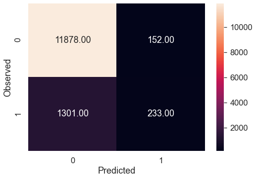

```
None

Recall: 0.15189048239895697

Precision: 0.6051948051948052

F1 Score: 0.24283480979676914

Roc Auc Score: 0.5696277017148568
```

```python
print("Trainig accuracy",logreg.score(x_train,y_train))
print()
print("Testing accuracy",logreg.score(x_test, y_test))
print()
print('Confusion Matrix')
print(draw_cm(y_test,y_predict))
print()
print("Recall:",recall_score(y_test,y_predict))
print()
print("Precision:",precision_score(y_test,y_predict))
print()
print("F1 Score:",f1_score(y_test,y_predict))
print()
print("Roc Auc Score:",roc_auc_score(y_test,y_predict))
```

## Decision Tree

```python
from sklearn.tree import DecisionTreeClassifier
from sklearn import tree
from os import system
from sklearn.feature_extraction.text import CountVectorizer
```

```python
model_entropy=DecisionTreeClassifier(criterion='entropy')
```

```python
df_tree = df.copy()
model_entropy.fit(x_train, y_train)
```

```
DecisionTreeClassifier(criterion='entropy')
```

```python
model_entropy.score(x_train, y_train)
```

```
1.0
```

```python
model_entropy.score(x_test, y_test)
```

```
0.8265260984960189
```

```python
model_pruned = DecisionTreeClassifier(criterion = "entropy", random_state = 7, max_depth = 3, min_samples_leaf=5)
model_pruned.fit(x_train, y_train)
model_pruned.score(x_train, y_train)
```

```
0.8925332574967612
```

```python
from sklearn.tree import export_graphviz
# from sklearn.externals.six import StringIO
from io import StringIO
from IPython.display import Image
import pydotplus
import graphviz

xvar = df_clean1.drop('Target', axis=1)
xvar = pd.get_dummies(xvar, drop_first=True)
feature_cols = xvar.columns
feature_cols
```

```
Index(['age', 'education', 'default', 'balance', 'housing', 'loan', 'day',
       'campaign', 'pdays', 'previous', 'job_blue-collar', 'job_entrepreneur',
       'job_housemaid', 'job_management', 'job_retired', 'job_self-employed',
       'job_services', 'job_student', 'job_technician', 'job_unemployed',
       'job_unknown', 'marital_married', 'marital_single', 'month_aug',
       'month_dec', 'month_feb', 'month_jan', 'month_jul', 'month_jun',
       'month_mar', 'month_may', 'month_nov', 'month_oct', 'month_sep',
       'poutcome_other', 'poutcome_success', 'poutcome_unknown'],
      dtype='object')
```

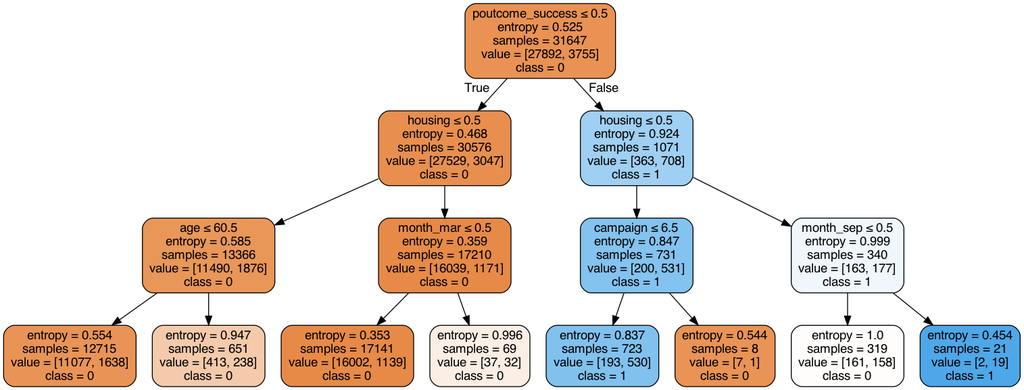

```python
dot_data = StringIO()
export_graphviz(model_pruned, out_file=dot_data,
                filled=True, rounded=True,
                special_characters=True,feature_names = feature_cols,class_names=['0','1'])
graph = pydotplus.graph_from_dot_data(dot_data.getvalue())
graph.write_png('model_pruned.png')
Image(graph.create_png())
```

```python
preds_pruned = model_pruned.predict(x_test)
preds_pruned_train = model_pruned.predict(x_train)
acc_DT = accuracy_score(y_test, preds_pruned)
print(accuracy_score(y_test, preds_pruned))
print(accuracy_score(y_train, preds_pruned_train))
```

```
0.8936154526688292
0.8925332574967612
```

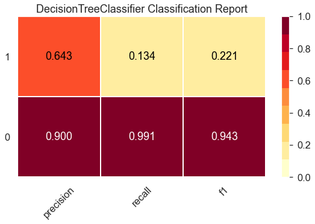

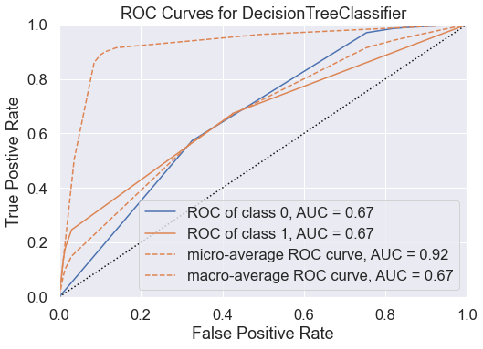

```python
# Visualize model performance with yellowbrick library
viz = ClassificationReport(DecisionTreeClassifier(criterion = "entropy", max_depth=3))
viz.fit(x_train, y_train)
viz.score(x_test, y_test)
viz.show()

roc = ROCAUC(DecisionTreeClassifier(criterion = "entropy", max_depth=3))
roc.fit(x_train, y_train)
roc.score(x_test, y_test)
roc.show()
```

```python
## Calculating feature importance

feat_importance = model_pruned.tree_.compute_feature_importances(normalize=False)


feat_imp_dict = dict(zip(X, model_pruned.feature_importances_))
feat_imp = pd.DataFrame.from_dict(feat_imp_dict, orient='index')
feat_imp.sort_values(by=0, ascending=False)
```

|  | 0 |
| --- | --- |
| poutcome_success | 0.70 |
| housing | 0.18 |
| age | 0.08 |
| month_mar | 0.03 |
| month_sep | 0.01 |
| campaign | 0.00 |
| month_jul | 0.00 |
| marital_single | 0.00 |
| month_aug | 0.00 |
| month_dec | 0.00 |
| month_feb | 0.00 |
| month_jan | 0.00 |
| month_may | 0.00 |
| month_jun | 0.00 |
| job_unknown | 0.00 |
| month_nov | 0.00 |
| month_oct | 0.00 |
| poutcome_other | 0.00 |
| marital_married | 0.00 |
| job_technician | 0.00 |
| job_unemployed | 0.00 |
| job_blue-collar | 0.00 |
| default | 0.00 |
| balance | 0.00 |
| loan | 0.00 |
| day | 0.00 |
| pdays | 0.00 |
| previous | 0.00 |
| job_entrepreneur | 0.00 |
| education | 0.00 |
| job_housemaid | 0.00 |
| job_management | 0.00 |
| job_retired | 0.00 |
| job_self-employed | 0.00 |
| job_services | 0.00 |
| job_student | 0.00 |
| poutcome_unknown | 0.00 |

### From the feature importance dataframe we can infer that poutcome_success, housing, and age are variables that impact our target variable

```python
#Store the accuracy results for each model in a dataframe for final comparison
resultsDf = pd.DataFrame({'Method':['Decision Tree'], 'accuracy': acc_DT})
resultsDf = resultsDf[['Method', 'accuracy']]
resultsDf
```

|  | Method | accuracy |
| --- | --- | --- |
| 0 | Decision Tree | 0.89 |

## Random Forest Model

```python
rfcl = RandomForestClassifier(n_estimators = 50)
rfcl = rfcl.fit(x_train, y_train)
```

```python
pred_RF = rfcl.predict(x_test)
acc_RF = accuracy_score(y_test, pred_RF)
```

```python
tempResultsDf = pd.DataFrame({'Method':['Random Forest'], 'accuracy': [acc_RF]})
resultsDf = pd.concat([resultsDf, tempResultsDf])
resultsDf = resultsDf[['Method', 'accuracy']]
resultsDf
```

|  | Method | accuracy |
| --- | --- | --- |
| 0 | Decision Tree | 0.89 |
| 0 | Random Forest | 0.89 |

## Apply Adaboost Ensemble Algorithm for the same data.

```python
from sklearn.ensemble import AdaBoostClassifier
abcl = AdaBoostClassifier(n_estimators = 100, learning_rate=0.1, random_state=7)
abcl = abcl.fit(x_train, y_train)
```

```python
pred_AB =abcl.predict(x_test)
acc_AB = accuracy_score(y_test, pred_AB)
```

```python
tempResultsDf = pd.DataFrame({'Method':['Adaboost'], 'accuracy': [acc_AB]})
resultsDf = pd.concat([resultsDf, tempResultsDf])
resultsDf = resultsDf[['Method', 'accuracy']]
resultsDf
```

|  | Method | accuracy |
| --- | --- | --- |
| 0 | Decision Tree | 0.89 |
| 0 | Random Forest | 0.89 |
| 0 | Adaboost | 0.89 |

### Apply Bagging Classifier Algorithm and print the accuracy.

```python
from sklearn.ensemble import BaggingClassifier

bgcl = BaggingClassifier(n_estimators=50, max_samples= .7, bootstrap=True, oob_score=True, random_state=7)
bgcl = bgcl.fit(x_train, y_train)
```

```python
pred_BG = bgcl.predict(x_test)
acc_BG = accuracy_score(y_test, pred_BG)
```

```python
tempResultsDf = pd.DataFrame({'Method':['Bagging'], 'accuracy': [acc_BG]})
resultsDf = pd.concat([resultsDf, tempResultsDf])
resultsDf = resultsDf[['Method', 'accuracy']]
resultsDf
```

|  | Method | accuracy |
| --- | --- | --- |
| 0 | Decision Tree | 0.89 |
| 0 | Random Forest | 0.89 |
| 0 | Adaboost | 0.89 |
| 0 | Bagging | 0.89 |

### Apply GradientBoost Classifier Algorithm for the same data and print the accuracy

```python
from sklearn.ensemble import GradientBoostingClassifier
gbcl = GradientBoostingClassifier(n_estimators = 50, learning_rate = 0.1, random_state=7)
gbcl = gbcl.fit(x_train, y_train)
```

```python
pred_GB = gbcl.predict(x_test)
acc_GB = accuracy_score(y_test, pred_GB)
```

```python
tempResultsDf = pd.DataFrame({'Method':['Gradient Boost'], 'accuracy': [acc_GB]})
resultsDf = pd.concat([resultsDf, tempResultsDf])
resultsDf = resultsDf[['Method', 'accuracy']]
resultsDf
```

|  | Method | accuracy |
| --- | --- | --- |
| 0 | Decision Tree | 0.89 |
| 0 | Random Forest | 0.89 |
| 0 | Adaboost | 0.89 |
| 0 | Bagging | 0.89 |
| 0 | Gradient Boost | 0.89 |